# DATA100 Introduction to Data Analytics

Lecture 4: Visualization - Day 1

Agassi Iu

Wilfrid Laurier University

2026-09-22

## Where we are

In this week, I will give you a working template for plots. This chapter explains *why* that template works.

**My Plan**

I hope that once you’ve seen the seven slots, these plots will stop looking like new syntax to memorize.

## Setup

```r
library(tidyverse)
```

We’ll work mostly with two datasets that ship with ggplot2:

- `mpg` — 234 car models, 11 variables
- `diamonds` — ~54,000 diamonds

```r
mpg |> select(manufacturer, model, displ, hwy, class, drv) |> head(4)
```

```
# A tibble: 4 × 6
  manufacturer model displ   hwy class   drv
  <chr>        <chr> <dbl> <int> <chr>   <chr>
1 audi         a4      1.8    29 compact f
2 audi         a4      1.8    29 compact f
3 audi         a4      2      31 compact f
4 audi         a4      2      30 compact f
```

# Data set

## Data

Every `ggplot()` call starts with the same first argument: a data frame (or tibble).

```r
ggplot(data = mpg) +
  geom_point(aes(x = displ, y = hwy))
```

`mpg` fills in `<DATA>` from the template. Nothing gets drawn until ggplot2 knows *which* data frame to pull the variables `displ` and `hwy` out of the mappings in `aes()`.

## Data can change per layer

`ggplot(data = ...)` sets the **default** data for every layer. Any geom can override it with its own `data` argument:

```r
ggplot(data = mpg, aes(x = displ, y = hwy)) +
  geom_point() +
  geom_point(data = mpg |> filter(class == "2seater"), color = "red")
```

The first layer inherits `mpg` from `ggplot()`; the second layer supplies its own filtered data frame instead. Same idea you’ll see again in the Layers section:

- data is a slot you can fill once globally, or override locally.

## The pipe: `|>`

The symbol `|>` takes what’s on its left and feeds it in as the **first argument** of the function on its right.

```r
mpg |> select(manufacturer, model, displ, hwy)

# is exactly the same as:
select(mpg, manufacturer, model, displ, hwy)
```

## Analogy

**If you like math…**

Think of a two-variable function $f(x, y)$.

**Connecting back to coding**

When we write `mpg |> filter(...) |> select(...)`, we’re doing the same thing: treating `mpg` like the input we’re plugging in, and `filter(...)`, `select(...)` like functions waiting to receive it as their first argument.

## The Pipe Chain

You can chain several steps and get something that reads top-to-bottom, roughly like “take `mpg`, *then* filter it, *then* select these columns”, instead of nesting function calls inside each other.

```r
mpg |>
  filter(class == "suv") |>
  select(model, displ, hwy) |>
  arrange(desc(hwy))
```

**Note**

This is R’s native pipe (base R ≥ 4.1). You may also see `%>%` in older code or tutorials. They serve the same purpose.

# Aesthetic mappings

## Mapping a variable to an aesthetic

An **aesthetic** is a visual property of the marks on the plot: position, color, shape, size, transparency.

`aes()` says “let this variable *control* that property.”

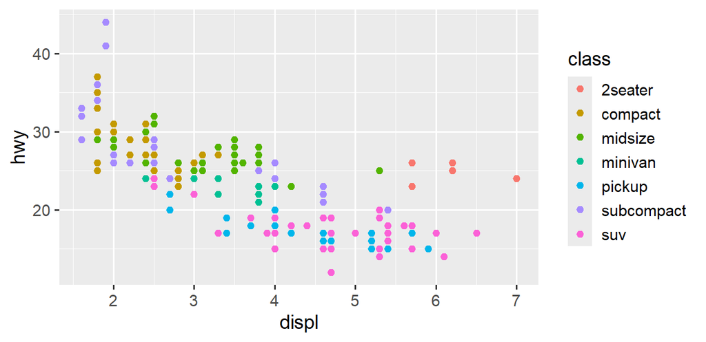

```r
ggplot(mpg, aes(x = displ, y = hwy, color = class)) +
  geom_point()
```

## Not every aesthetic suits

You can change the shape of scatterplots from circles to triangles, stars, squares, etc.

But `shape` only supplies six distinct symbols before it gives up: the seventh category simply goes unplotted, with a warning.

```r
ggplot(mpg, aes(x = displ, y = hwy, shape = class)) +
  geom_point()
```

```
Warning: The shape palette can deal with a maximum of 6 discrete values because more
than 6 becomes difficult to discriminate
ℹ you have requested 7 values. Consider specifying shapes manually if you need
  that many of them.
```

```
Warning: Removed 62 rows containing missing values or values outside the scale range
(`geom_point()`).
```

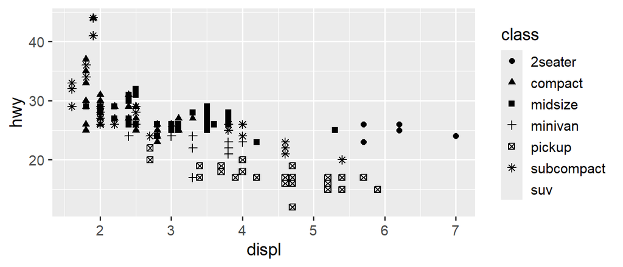

## Problems with shape levels

**Warning**

`class` has seven levels but `shape` can only display six. SUVs (62 rows) silently disappear from the plot above. You should always read the warnings `ggplot2` gives you, they’re telling you data went missing from the picture.

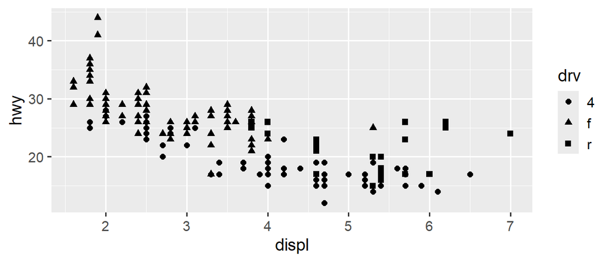

```r
ggplot(mpg, aes(x = displ, y = hwy, shape = drv)) +
  geom_point()
```

## Point customization

**Checkpoint**

What do you think `size` and `alpha` does?

- `size` changes the size of the dot (smaller-larger)
- `alpha` changes the transparency of the dot (lighter-darker)
- These two aesthetics are *ranked*.

## Ordered aesthetics

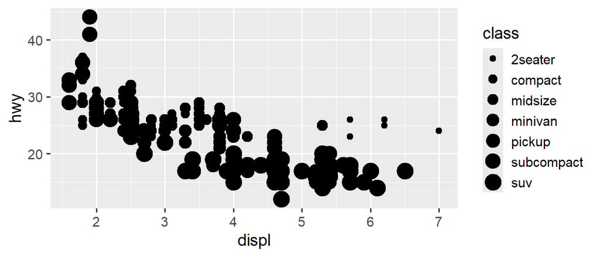

```r
ggplot(mpg, aes(x = displ, y = hwy, size = class)) +
  geom_point()
```

**Mapping an unordered category**

`class` (e.g. 2seater, compact, midsize, …) has no inherent order. Mapping it to `size` or `alpha` visually implies “bigger/darker = more,” which is misleading for a purely categorical variable. Save these aesthetics for variables that are genuinely ordered or continuous.

## Mapping vs. setting

Inside `aes()` = mapping, driven by data, gets a legend. Outside `aes()` = setting, a fixed constant, no legend.

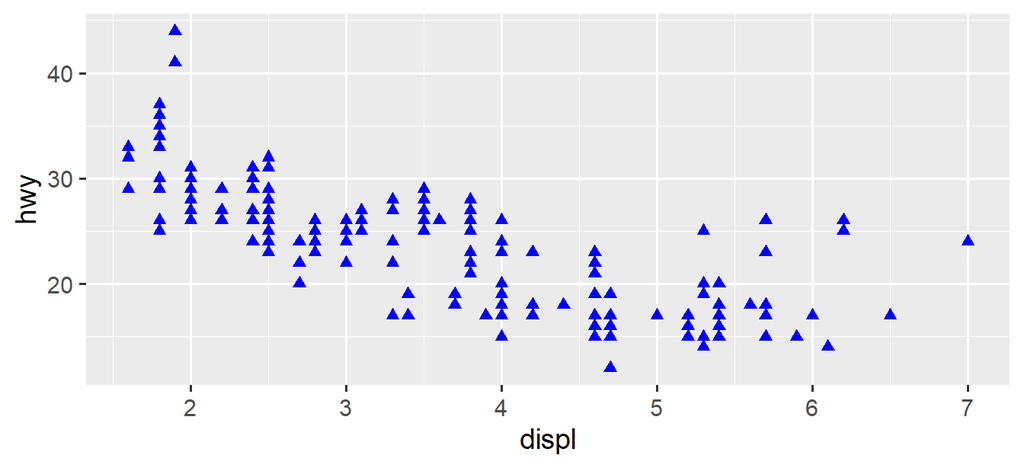

```r
ggplot(mpg, aes(x = displ, y = hwy)) +
  geom_point(color = "blue", size = 2, shape = 17)
```

## Setting values

When you set an aesthetic you supply a raw value:

| Aesthetic | Value |
| --- | --- |
| `color` | colour name `"blue"` or hex string `"#E81B23"` |
| `size` | point size in mm, `size = 1` |
| `shape` | an integer 0–25, `shape = 1` |
| `alpha` | opacity from 0 to 1 |

Shapes 0–14 are hollow (border from `color`), 15–20 are solid (filled with `color`), and 21–25 take both a `color` border and a `fill`.

## Your turn

**Try it yourself**

1. Draw `hwy` vs. `displ` with pink filled triangles.
2. Why does the code below *not* produce blue points?
3. What happens with `aes(color = displ < 5)`?

```r
ggplot(mpg) +
  geom_point(aes(x = displ, y = hwy, color = "blue"))
```

# Geometric objects

## A geom is how the data gets drawn

Same data, same mappings, different geom:

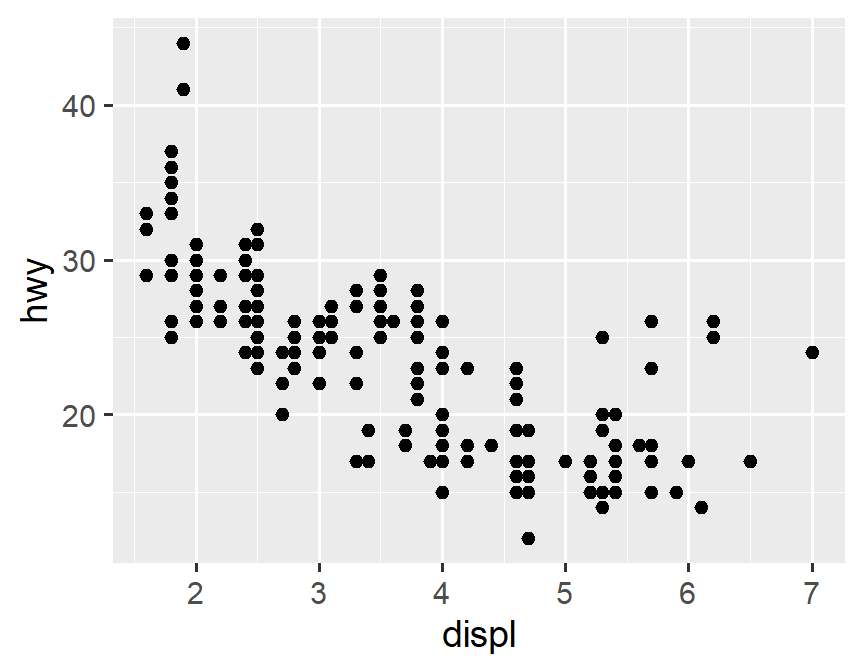

```r
ggplot(mpg, aes(displ, hwy)) +
  geom_point()
```

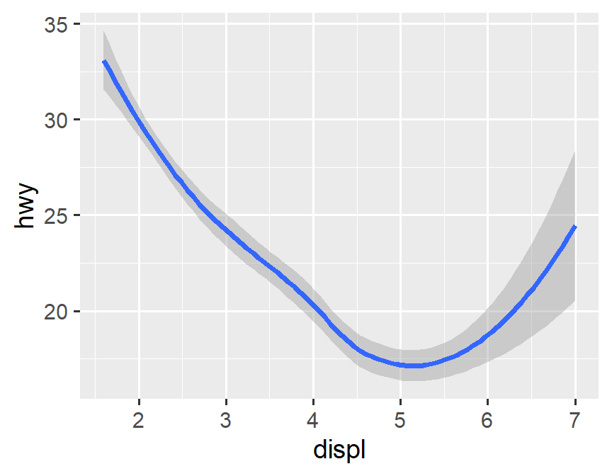

```r
ggplot(mpg, aes(displ, hwy)) +
  geom_smooth()
```

## Geoms accept different aesthetics

A line has no shape; a point has no linetype. `ggplot2` quietly ignores aesthetics a geom can’t use.

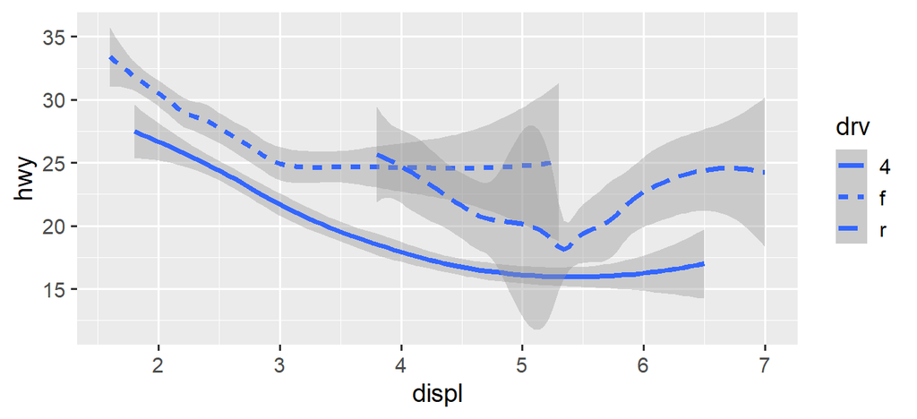

```r
ggplot(mpg, aes(x = displ, y = hwy, linetype = drv)) +
  geom_smooth()
```

Mapping a discrete variable splits the geom into one object per level.

## Grouping without a legend

`group` splits the data the same way, but adds no legend and no visual distinction.

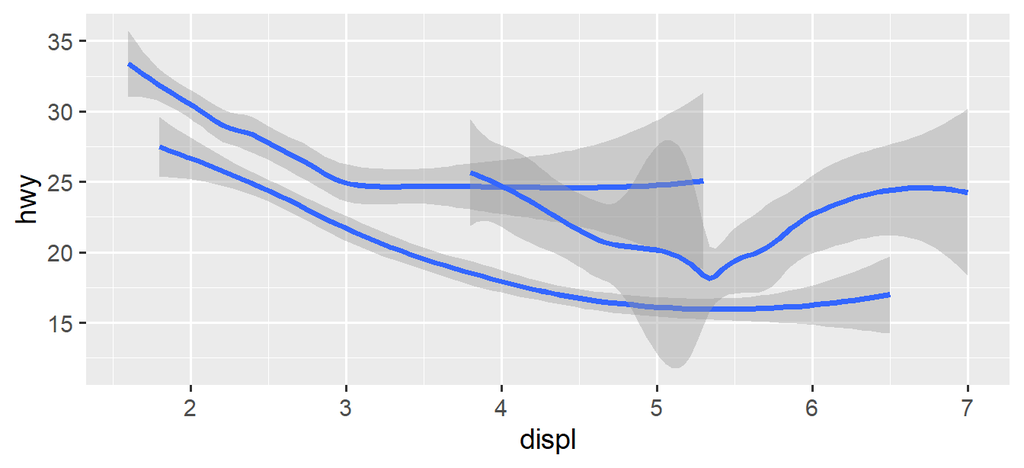

```r
ggplot(mpg, aes(x = displ, y = hwy)) +
  geom_smooth(aes(group = drv))
```

**Note**

`group` is what mapping a discrete variable does *implicitly* behind the scenes. You should use it when you want the splitting behaviour without the legend or the visual distinction that `color` or `linetype` would add.

## Layers stack

Multiple geoms in one plot. Mappings in `ggplot()` are global; mappings in a geom are local to that layer.

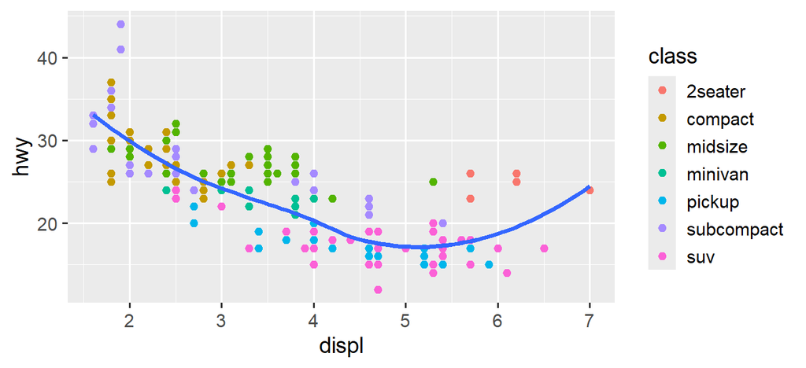

```r
ggplot(mpg, aes(x = displ, y = hwy)) +
  geom_point(aes(color = class)) +
  geom_smooth(se = FALSE)
```

## Layers can have their own data

Useful for highlighting a subset:

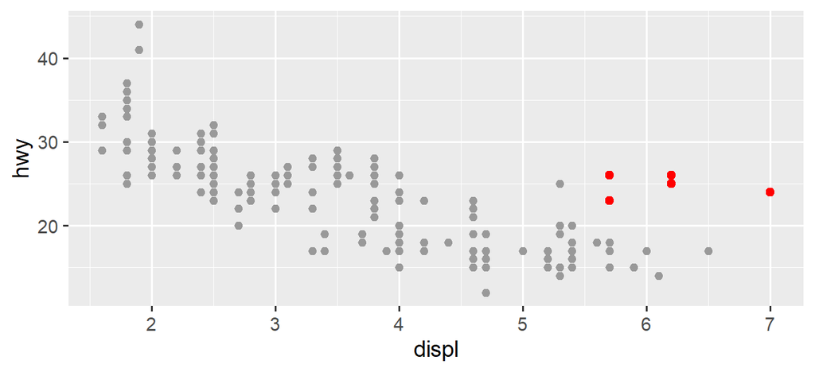

```r
ggplot(mpg, aes(x = displ, y = hwy)) +
  geom_point(color = "grey60") +
  geom_point(
    data = mpg |> filter(class == "2seater"),
    color = "red", size = 2
  )
```

## Different geoms

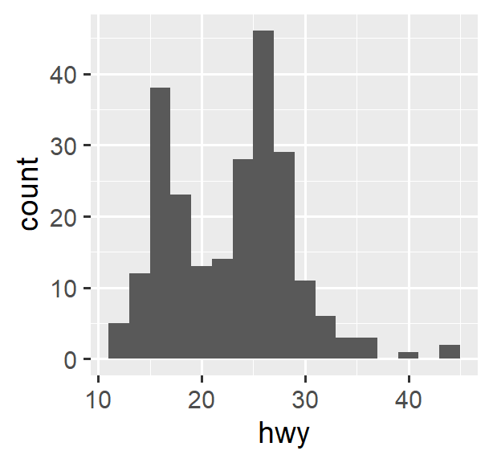

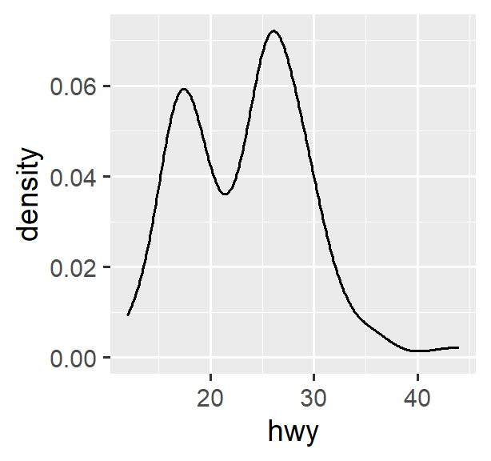

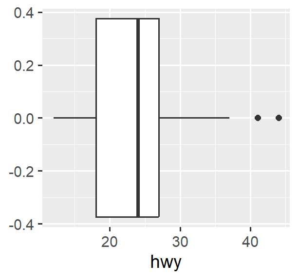

```r
ggplot(mpg, aes(x = hwy)) + geom_histogram(binwidth = 2)
ggplot(mpg, aes(x = hwy)) + geom_density()
ggplot(mpg, aes(x = hwy)) + geom_boxplot()
```

The histogram and density show *bimodality* and *right skew*; the boxplot compresses that into a summary but flags outliers.

## Common geoms at a glance

| Chart type | Geom | What it draws |
| --- | --- | --- |
| Line chart | `geom_line()` | Connects points in order of the x-value — good for trends over a continuous sequence (e.g. time) |
| Bar plot | `geom_bar()` | Counts observations per category and draws bar height as the count (uses `stat_count()`) |
| Bar plot (pre-counted) | `geom_col()` | Bar height comes directly from a `y` column you already have — no counting |
| Histogram | `geom_histogram()` | Bins a *continuous* variable and draws bar height as the count per bin |
| Boxplot | `geom_boxplot()` | Five-number summary (min, Q1, median, Q3, max) plus outliers, per group |
| Area chart | `geom_area()` | Like `geom_line()`, but fills the region under the line |

## Boxplots

A boxplot summarizes a distribution with five numbers: the minimum, the first quartile (Q1), the median, the third quartile (Q3), and the maximum. Points far from the rest get drawn separately as individual outliers.

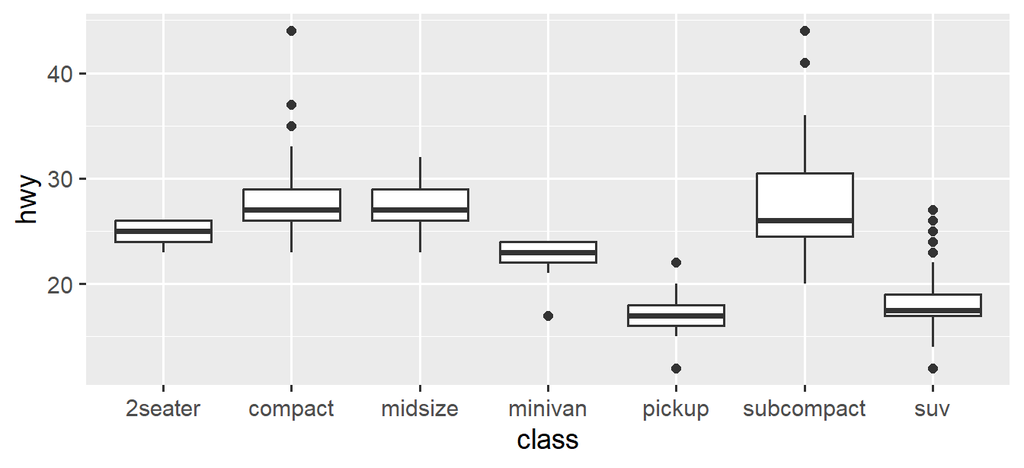

```r
ggplot(mpg, aes(x = class, y = hwy)) +
  geom_boxplot()
```

## Reading a boxplot

**What each part means**

- The **box** spans Q1 to Q3, the middle 50% of the data (the interquartile range, or IQR).
- The **line inside the box** is the median.
- The **whiskers** extend to the farthest point still within 1.5 times the IQR from the box.
- **Dots beyond the whiskers** are flagged as outliers.

**Tip**

A boxplot is a compression. It tells you center and spread at a glance, but it can’t show you whether a group has one peak or several, since all of that shape detail gets collapsed into five numbers.

## Violin plots

A violin plot replaces the box with a mirrored density curve, so you see the full shape of the distribution instead of just a summary.

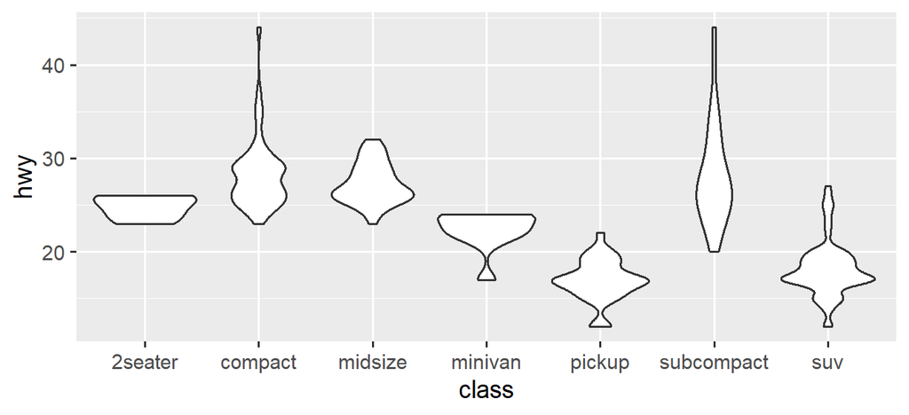

```r
ggplot(mpg, aes(x = class, y = hwy)) +
  geom_violin()
```

## Boxplot vs. violin plot

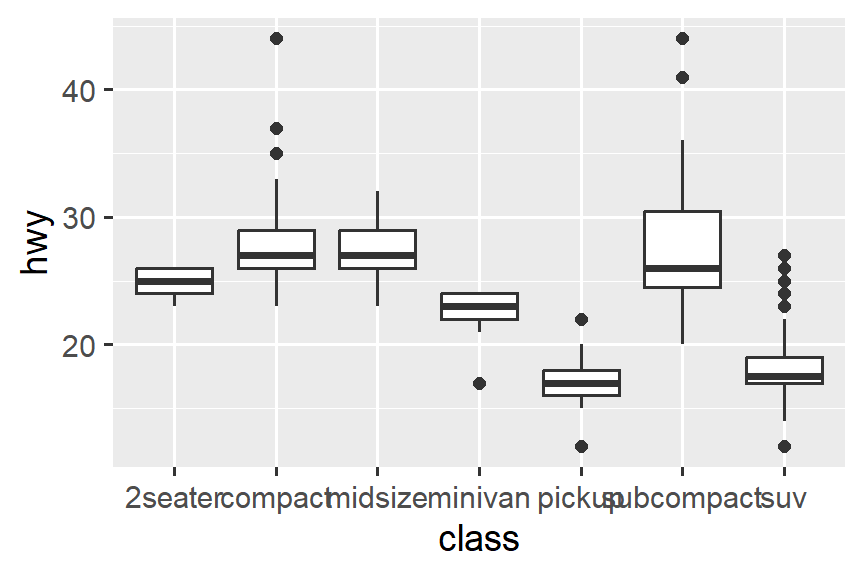

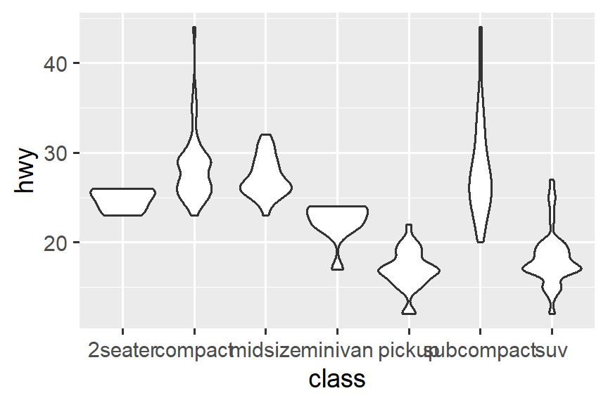

```r
ggplot(mpg, aes(x = class, y = hwy)) + geom_boxplot()
ggplot(mpg, aes(x = class, y = hwy)) + geom_violin()
```

## Boxplot vs violin plot

**Important**

Use a boxplot when you mainly care about comparing medians and spread across many groups at once, it stays compact even with a dozen categories side by side.

Use a violin plot when the shape itself matters, for example spotting bimodal groups, since a boxplot cannot distinguish “spread out evenly” from “two separate clusters.”

**Caution**

Violin plots need enough points per group to draw a reliable density curve. With a small group, the “shape” you see may just be noise from too few observations, not a real pattern.

## Try out different plots

**Try it yourself**

# Facets

## `facet_wrap()`: one variable

What if we are interested in how each class of variables behave? We can split the plot into panels with one per level.

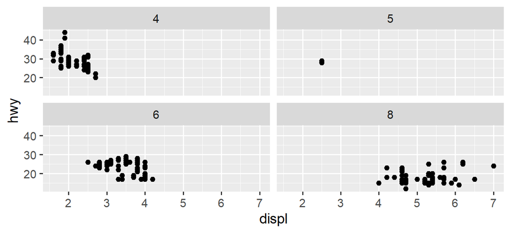

```r
ggplot(mpg, aes(x = displ, y = hwy)) +
  geom_point() +
  facet_wrap(~cyl)
```

## `facet_grid()`: two variables

A two-sided formula, `rows ~ cols`.

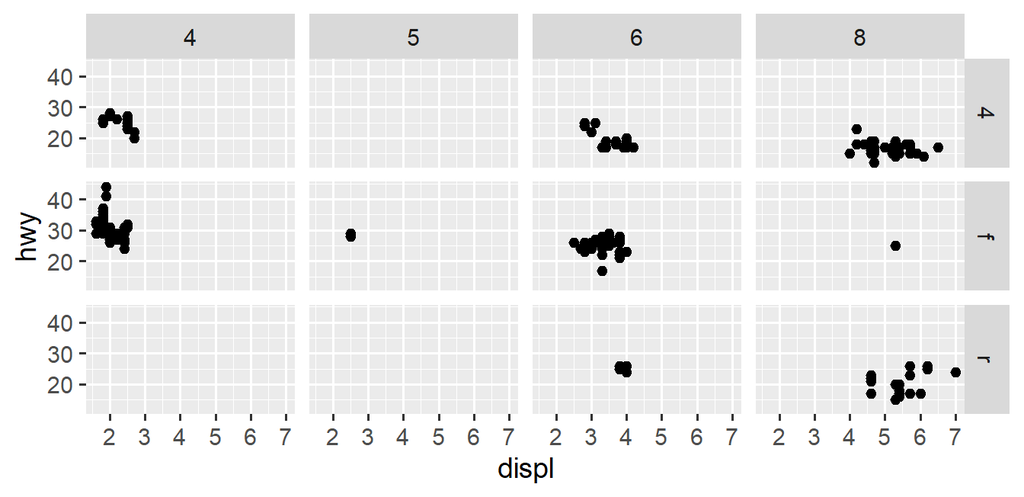

```r
ggplot(mpg, aes(x = displ, y = hwy)) +
  geom_point() +
  facet_grid(drv ~ cyl)
```

Empty panels mean that combination doesn’t occur in the data.

## Free scales

By default every panel shares one scale, which is what makes panels comparable. Release that with `scales`:

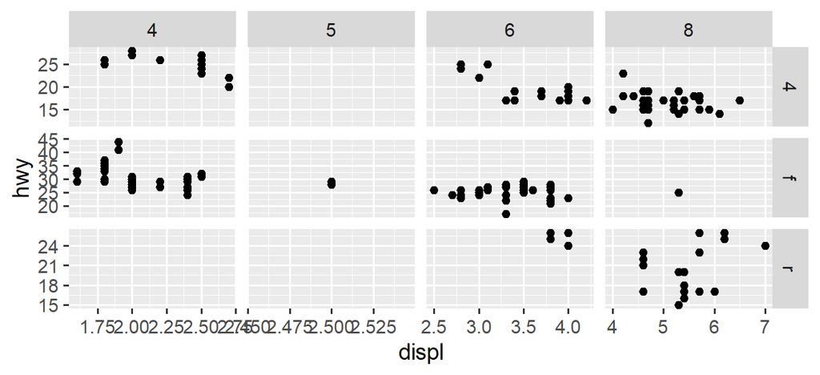

```r
ggplot(mpg, aes(x = displ, y = hwy)) +
  geom_point() +
  facet_grid(drv ~ cyl, scales = "free")
```

## Free scales

**Customization**

`"free_x"`, `"free_y"`, or `"free"` let each row/column pick its own range.

- This is easier to read within a panel, but panels are no longer directly comparable to each other.

**Checkpoint**

If I want to share a plot with someone that has no idea about the data set, should I use free scales or shared scales?

## Your turn

**Try it yourself**

1. What happens if you facet on a continuous variable like `cty`?
2. What does `.` mean in `facet_grid(drv ~ .)`?

# Statistical transformations

## Where does `count` come from?

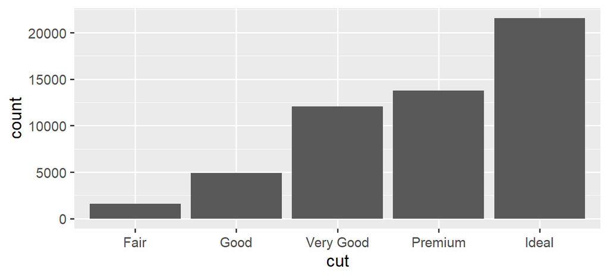

```r
ggplot(diamonds, aes(x = cut)) +
  geom_bar()
```

`count` isn’t a column in `diamonds`. The `geom_bar` computed it.

## Stats

A **stat** is the algorithm a geom runs on your data before drawing.

- bar charts, histograms, freqpolys → bin and count
- smoothers → fit a model, plot predictions
- boxplots → compute a five-number summary

Every geom has a default stat; every stat has a default geom. `?geom_bar` tells you it uses `stat_count()`, and lists the variables it computes.

## Overriding the stat

When you already have the counts, switch to the identity stat (or use `geom_col()`):

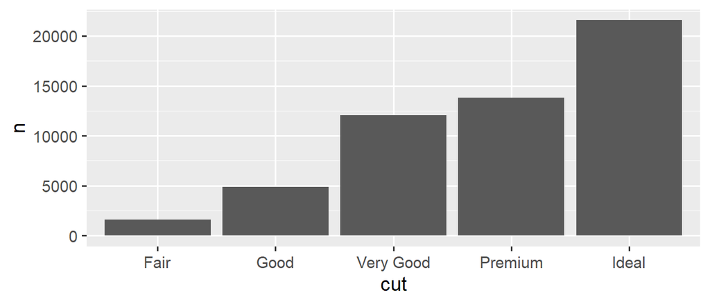

```r
diamonds |>
  count(cut) |>
  ggplot(aes(x = cut, y = n)) +
  geom_bar(stat = "identity")
```

## Using a computed variable

`after_stat()` reaches into the variables the stat produced. The `prop` means proportion.

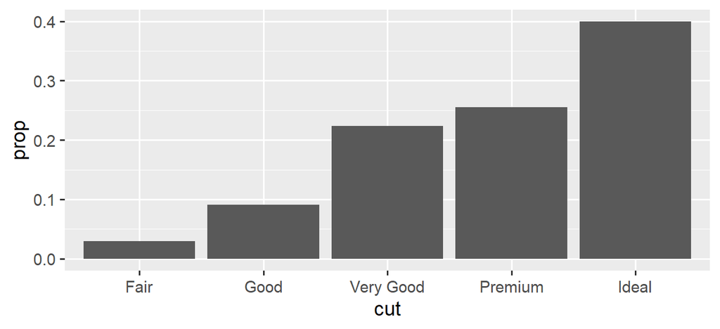

```r
ggplot(diamonds, aes(x = cut, y = after_stat(prop), group = 1)) +
  geom_bar()
```

## `group` issue

**Important**

## Calling a stat directly

Sometimes the summary *is* the point, and naming the stat says so:

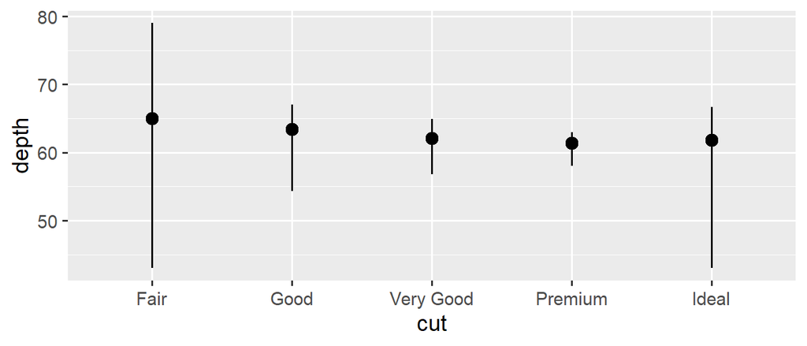

```r
ggplot(diamonds) +
  stat_summary(
    aes(x = cut, y = depth),
    fun.min = min, fun.max = max, fun = median
  )
```

## Your turn

**Try it yourself**

# Position adjustments

## `color` vs. `fill` for bars

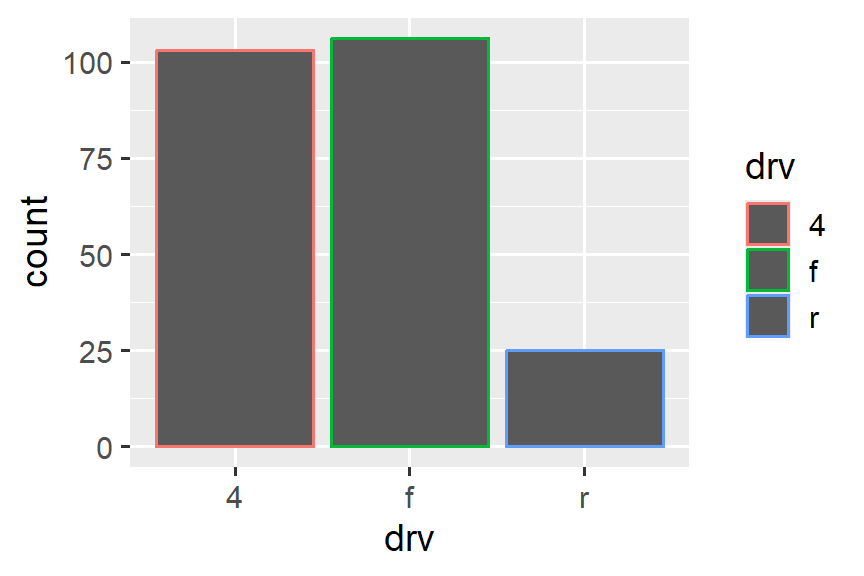

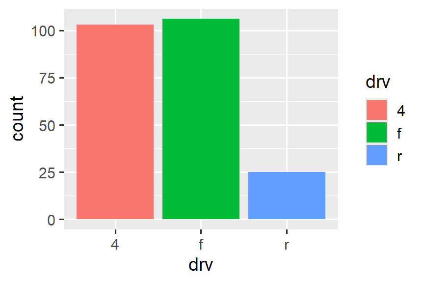

```r
ggplot(mpg, aes(x = drv, color = drv)) + geom_bar()
ggplot(mpg, aes(x = drv, fill = drv)) + geom_bar()
```

## Stacking is a position adjustment

Map `fill` to a second variable and the bars stack automatically:

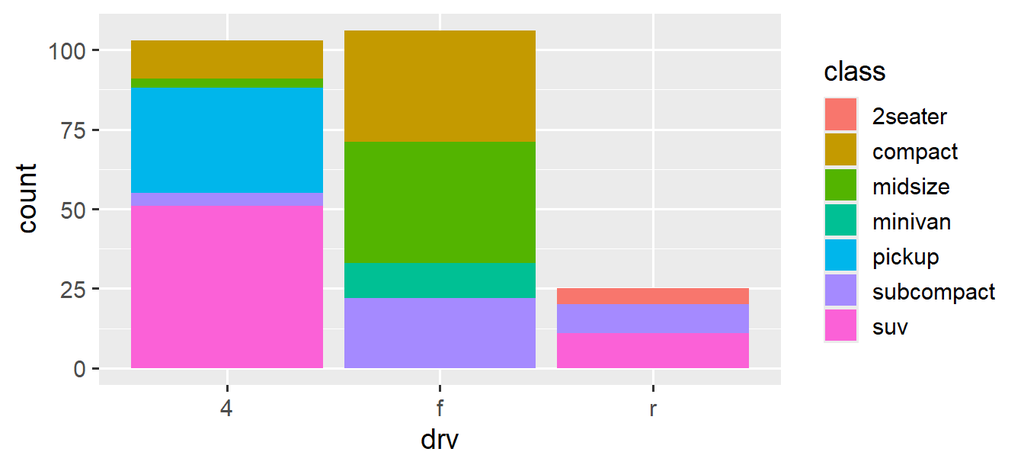

```r
ggplot(mpg, aes(x = drv, fill = class)) +
  geom_bar()
```

## The four options

**Stack**

**`"stack"`** — the default for bars. Segments pile on top of each other in full-height, full-count form.

**Fill**

**`"fill"`** — stack, then normalize each bar to the same height. Best for comparing **proportions** across groups, since every bar reaches 100%.

**Dodge**

**`"dodge"`** — segments sit side by side instead of stacking. Best for comparing **individual counts** directly, since bar heights stay on the original count scale.

**Identity**

**`"identity"`** — draws each value exactly where it falls, with no adjustment. For bars this usually means overlapping rectangles (rarely what you want); for points, it’s the default position since points have no width to adjust.

## Exercise

**Tip**

## Overplotting

`hwy` and `displ` are rounded, so points land on a grid and pile up. This scatterplot shows 126 visible points for 234 observations. The points are **overlapping**!

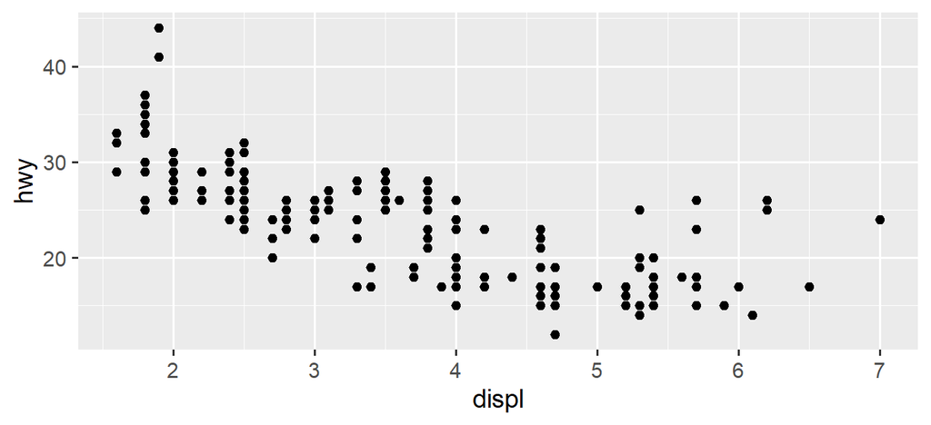

```r
ggplot(mpg, aes(x = displ, y = hwy)) +
  geom_point()
```

## Jittering

`position = "jitter"` adds a little random noise. Less accurate at small scales, far more honest at large ones.

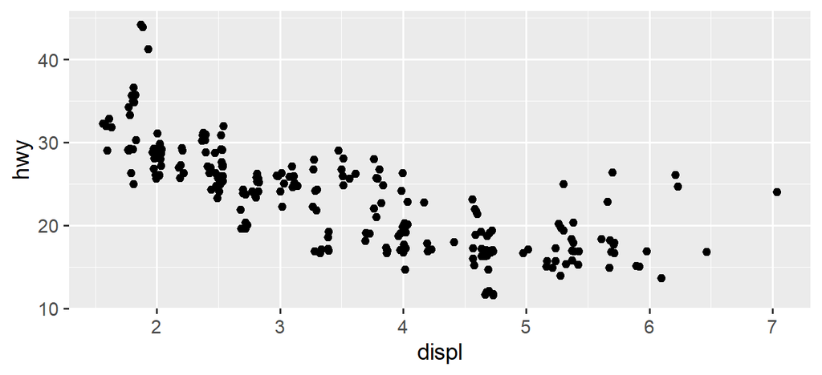

```r
ggplot(mpg, aes(x = displ, y = hwy)) +
  geom_jitter()
```

`geom_jitter()` is shorthand for `geom_point(position = "jitter")`.

## Your turn

**Try it yourself**

# Coordinate systems

## The default is Cartesian

x and y act independently. Two alternatives come up often enough to know:

- `coord_quickmap()`: fixes the aspect ratio for geographic data
- `coord_polar()`: bends the Cartesian plane into polar coordinates

```r
nz <- map_data("nz")

ggplot(nz, aes(x = long, y = lat, group = group)) +
  geom_polygon(fill = "white", color = "black") +
  coord_quickmap()
```

[output not shown]

## Polar coordinates

A bar chart and a Coxcomb chart are the same plot in different coordinates:

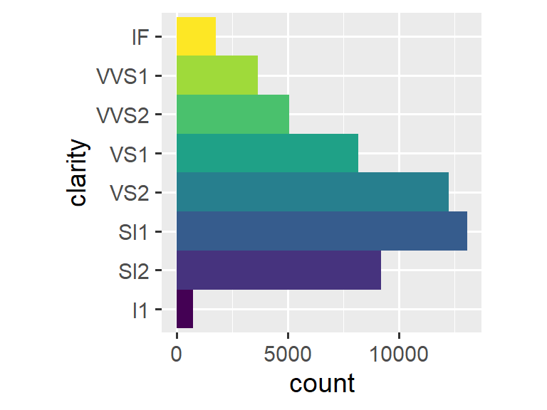

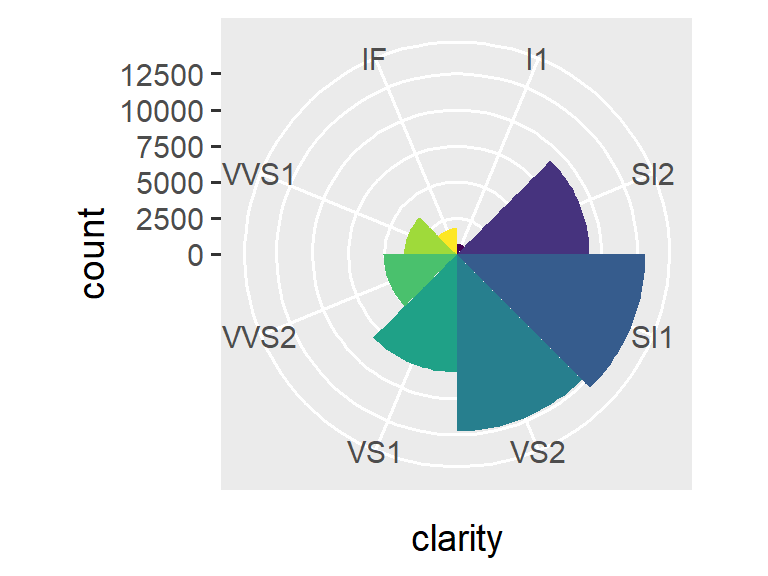

```r
bar <- ggplot(diamonds) +
  geom_bar(aes(x = clarity, fill = clarity), show.legend = FALSE, width = 1) +
  theme(aspect.ratio = 1)

bar + coord_flip()
bar + coord_polar()
```

# Putting it together

## The extended template

```r
ggplot(data = <DATA>) +
  <GEOM_FUNCTION>(
     mapping = aes(<MAPPINGS>),
     stat = <STAT>,
     position = <POSITION>
  ) +
  <COORDINATE_FUNCTION> +
  <FACET_FUNCTION>
```

There are seven slots. In practice you only fill in three: `data`, `mappings`, `geom`, because `ggplot2` supplies sensible defaults for the rest.

## Summary

- **Aesthetics** map variables to visual properties; setting differs from mapping
- **Geoms** decide how marks are drawn; layers stack and can override data and mappings
- **Facets** split one plot into comparable panels
- **Stats** compute the values a geom actually plots
- **Positions** resolve overlap: stack, fill, dodge, jitter
- **Coordinates** redefine what x and y mean

Still to come: **themes**, in Chapter 11 (next week).